# Лабораторная работа №8

Планировщики событий cron и at

Ришард Когенгар

Российский университет дружбы народов, Москва, Россия

20 января 2026

# Цель работы

## Основная цель

Получение практических навыков работы с планировщиками событий  
**cron** и **at** в операционной системе Linux.

# Ход выполнения работы

## Проверка службы crond

- Получены привилегии администратора
- Проверено состояние службы **crond**
- Служба загружена, включена в автозапуск
- Состояние: **active (running)**

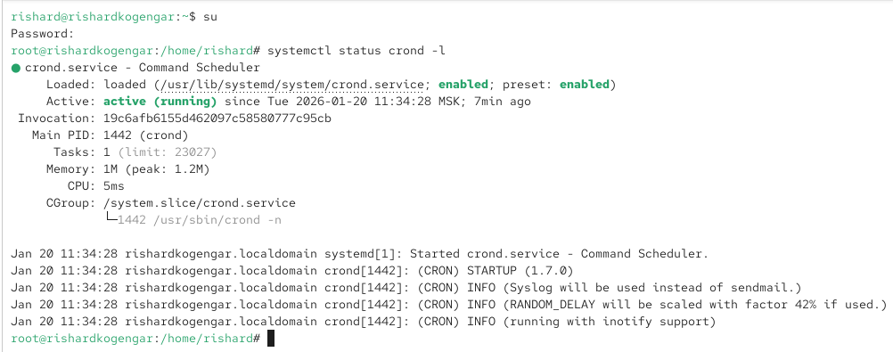

Проверка состояния службы crond

## Файл конфигурации /etc/crontab

- Просмотр глобального файла конфигурации cron
- Заданы переменные окружения:
  - **SHELL**
  - **PATH**
  - **MAILTO**
- Приведено описание формата заданий cron

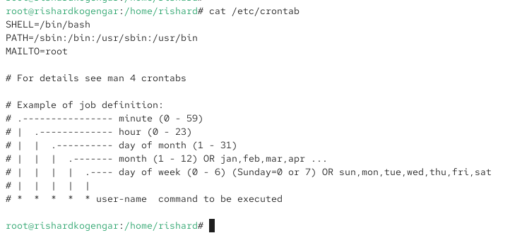

Просмотр содержимого /etc/crontab

## Пользовательское расписание cron

- Проверка пользовательского crontab
- Расписание отсутствует
- Создание нового задания через `crontab -e`

Добавлено задание: - Выполнение каждую минуту - Запись сообщения в системный журнал

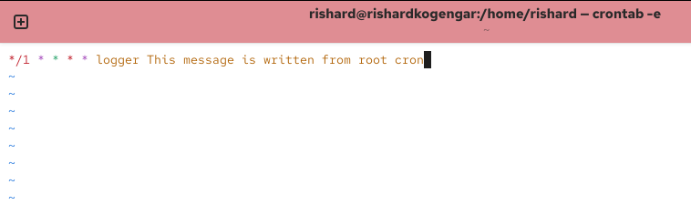

Редактирование пользовательского crontab

## Проверка выполнения cron-задания

- Просмотр текущего расписания
- Анализ системного журнала
- Зафиксированы регулярные записи в `/var/log/messages`
- Подтверждено корректное выполнение задания

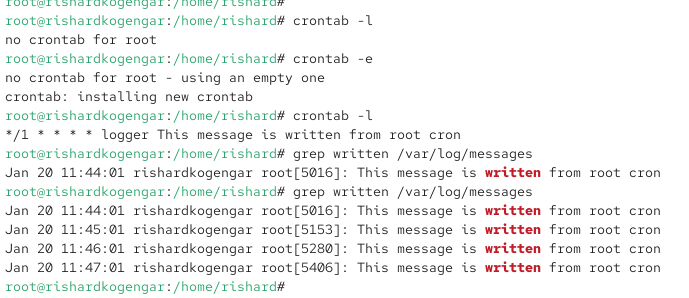

Проверка выполнения задания cron

## Изменение расписания cron

- Задание изменено на выполнение:
  - Каждый час
  - Только в рабочие дни
- Использовано ограничение по дням недели (1–5)

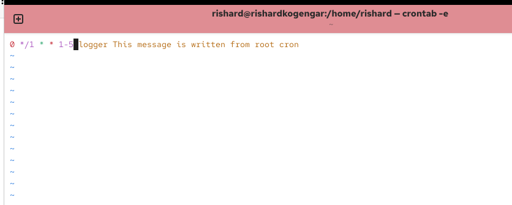

Изменение задания cron

## Каталог /etc/cron.hourly

- Создан сценарий **eachhour**
- Сценарий записывает сообщение в системный журнал
- Используется текущая дата и время

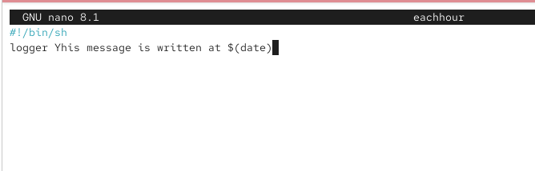

Создание сценария eachhour

## Каталог /etc/cron.d

- Создан файл расписания **eachhour**
- Задание выполняется каждый час
- Команда запускается от имени **root**
- Запуск на 11-й минуте часа

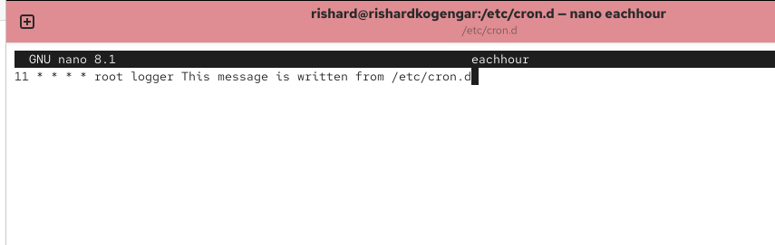

Настройка задания в /etc/cron.d

## Создание и выполнение задания at

- Создано разовое задание на заданное время
- Команда записывает сообщение в системный журнал
- Проверена очередь заданий
- Подтверждено выполнение по журналу

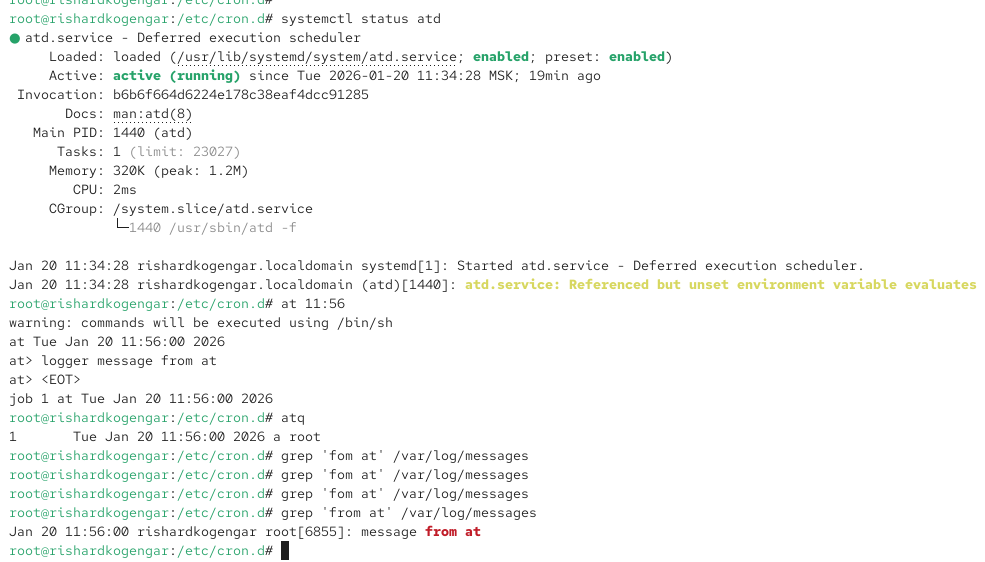

Проверка выполнения задания at

# Итоги работы

## Вывод

- Изучены механизмы планирования задач **cron** и **at**
- Настроены периодические и разовые задания
- Проверена работа системных служб **crond** и **atd**
- Подтверждено выполнение заданий по системному журналу